# Monty Hall Problem Model

Dan Conroy-Beam

2023-08-29

## Model Overview

### Purpose

Compare strategies within the Monty Hall Problem. Agents will take turns playing the guessing game from the Monty Hall problem.

The model will determine and store how the agent would have fared in each iteration had they used a stay or a switch strategy.

### Agents

Each iteration of the model will generate a single agent who will play one round of the guessing game from Let’s Make a Deal.

The agent will use, in parallel, both a stay and switch strategy in each round.

### Life Cycle

1. Setup
2. Guess
3. Reveal Goat
4. Stay/Switch
5. Reveal Car

#### Setup

At the start of the life cycle, “Monty Hall” will place a car behind one randomly selected door and goats behind the remaining doors.

#### Guess

During this stage, the agent will guess which door conceals the car. The agent will pick a random door each round.

#### Reveal Goat

After the agent’s initial guess, Monty Hall will reveal what is behind one of the doors. The revealed door will always (1) conceal a goat and (2) not be a door the agent has guessed.

#### Stay/Switch

At this stage, Monty Hall will ask the agent whether it wants to stay with its original guess or switch to the other, unrevealed door.

To save time, the model will separately store the result of both decisions.

#### Reveal Car

At this stage, Monty Hall will reveal which door concealed the car. If the agent’s decision was correct, the model will store this as a victory for that round. If the agent’s decision was incorrect, the model will store this as a loss for that round.

### Analysis

The model will compare the proportion of games in which the agent won the car with both strategies

## Model

### Packages

```r
library(ggplot2)
```

### Parameters

```r
#Model Loops#
#Number of times to repeat the model
modelLoops<-1000
```

### Life Cycle

```r
#Create a blank dataframe to store model results
results<-data.frame("stay"=rep(NA,modelLoops),"switch"=NA)

for (loop in 1:modelLoops) {

  #Setup#

  #Generate the door numbers
  number <- 1:3

  #Generate the prizes
  prizes <- c("car", "goat", "goat")

  #Randomly scramble the prize vector
  prizes <- sample(prizes, 3)

  #Generate the doors
  doors <- data.frame(number, prizes)



  #Guess#

  #Have the agent make an initial door guess
  startGuess <- sample(doors$number, 1)



  #Reveal Goat#

  #First identify which doors conceal a goat
  reveal <- doors$number[doors$prizes == "goat"]

  #If applicable, remove the agent's guess from the reveal options
  reveal <- reveal[reveal != startGuess]


  #If there is more than one revealable door...
  if (length(reveal) > 1) {
    #Then choose one of the doors to reveal at random
    reveal <- sample(reveal, 1)
  }



  #Stay/Switch#

  #Create a variable reflecting the agent's original guess
  stayGuess <- startGuess

  #Have the agent guess the door they did not originally guess and Monty did not reveal
  switchGuess <- doors$number[!(doors$number %in% c(stayGuess, reveal))]



  #Reveal Car#

  #Determine the prize when the agent switches their guess
  stayResult <- doors$prizes[stayGuess == doors$number]

  #Determine the prize when the agent switches their guess
  switchResult <- doors$prizes[switchGuess == doors$number]

  #Save the results of staying to the results dataframe
  results$stay[loop]<-stayResult

  #Save the results of switching to the results dataframe
  results$switch[loop]<-switchResult
}
```

### Analysis

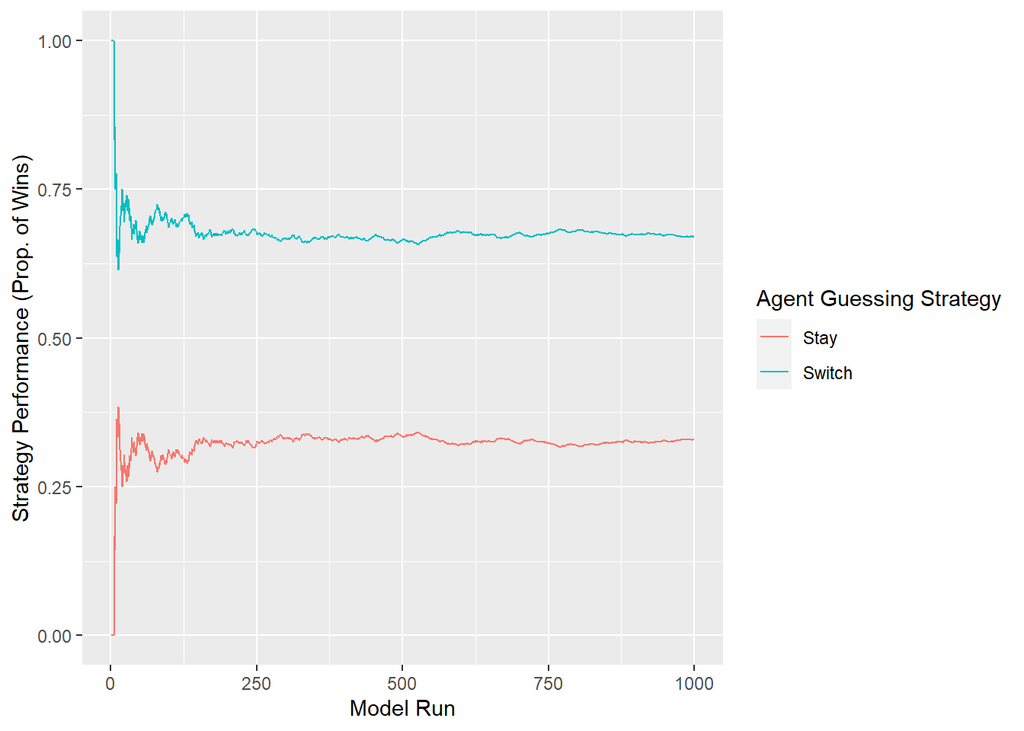

```r
#Converts cars to 1 and goats to 0
results<-ifelse(results=="car",1,0)

#Create a dataframe to plot model results
plotData<-data.frame("run"=1:modelLoops,
                     "strategy"=rep(c("Stay","Switch"),
                                    each=modelLoops),
                     "outcome"=c(cumsum(results[,1])/1:modelLoops,
                                 cumsum(results[,2])/1:modelLoops))


resultsPlot<-ggplot(data=plotData,
                    aes(x=run,
                        y=outcome,
                        color=strategy)
                    )+
  labs(x="Model Run",
       y="Strategy Performance (Prop. of Wins)",
       color="Agent Guessing Strategy")+
  geom_line()

resultsPlot
```